# 4. Transformacja danych.

#### Duplikaty

|  | pclass | survived | name | sex | age_raw | sibsp | parch | ticket | fare | cabin | embarked | boat | body | home.dest | age |
| --- | --- | --- | --- | --- | --- | --- | --- | --- | --- | --- | --- | --- | --- | --- | --- |
| 0 | 1.0 | 1.0 | Allen, Miss. Elisabeth Walton | female | 29.0000 | 0.0 | 0.0 | 24160 | 211.3375 | B5 | S | 2 | NaN | St Louis, MO | 29.0 |
| 1 | 1.0 | 1.0 | Allison, Master. Hudson Trevor | male | 0.9167 | 1.0 | 2.0 | 113781 | 151.5500 | C22 C26 | S | 11 | NaN | Montreal, PQ / Chesterville, ON | 1.0 |
| 2 | 1.0 | 0.0 | Allison, Miss. Helen Loraine | female | 2.0000 | 1.0 | 2.0 | 113781 | 151.5500 | C22 C26 | S | NaN | NaN | Montreal, PQ / Chesterville, ON | 2.0 |
| 3 | 1.0 | 0.0 | Allison, Mr. Hudson Joshua Creighton | male | 30.0000 | 1.0 | 2.0 | 113781 | 151.5500 | C22 C26 | S | NaN | 135.0 | Montreal, PQ / Chesterville, ON | 30.0 |
| 4 | 1.0 | 0.0 | Allison, Mrs. Hudson J C (Bessie Waldo Daniels) | female | 25.0000 | 1.0 | 2.0 | 113781 | 151.5500 | C22 C26 | S | NaN | NaN | Montreal, PQ / Chesterville, ON | 25.0 |
| ... | ... | ... | ... | ... | ... | ... | ... | ... | ... | ... | ... | ... | ... | ... | ... |
| 1299 | 3.0 | 0.0 | Yasbeck, Mr. Antoni | male | 27.0000 | 1.0 | 0.0 | 2659 | 14.4542 | NaN | C | C | NaN | NaN | 27.0 |
| 1300 | 3.0 | 1.0 | Yasbeck, Mrs. Antoni (Selini Alexander) | female | 15.0000 | 1.0 | 0.0 | 2659 | 14.4542 | NaN | C | NaN | NaN | NaN | 15.0 |
| 1303 | 3.0 | 0.0 | Yousseff, Mr. Gerious | male | NaN | 0.0 | 0.0 | 2627 | 14.4583 | NaN | C | NaN | NaN | NaN | NaN |
| 1304 | 3.0 | 0.0 | Zabour, Miss. Hileni | female | 14.5000 | 1.0 | 0.0 | 2665 | 14.4542 | NaN | C | NaN | 328.0 | NaN | 14.0 |
| 1305 | 3.0 | 0.0 | Zabour, Miss. Thamine | female | NaN | 1.0 | 0.0 | 2665 | 14.4542 | NaN | C | NaN | NaN | NaN | NaN |

596 rows × 15 columns

##### W numeracji biletów występują identyczne numery, jednak są przypisane do różnych osób o podobnych nazwiskach, co pozwala sądzić, że na jeden bilet przypisany był do kilku osób, np. rodziny.

|  | pclass | survived | name | sex | age_raw | sibsp | parch | ticket | fare | cabin | embarked | boat | body | home.dest | age |
| --- | --- | --- | --- | --- | --- | --- | --- | --- | --- | --- | --- | --- | --- | --- | --- |
| 725 | 3.0 | 1.0 | Connolly, Miss. Kate | female | 22.0 | 0.0 | 0.0 | 370373 | 7.7500 | NaN | Q | 13 | NaN | Ireland | 22.0 |
| 726 | 3.0 | 0.0 | Connolly, Miss. Kate | female | 30.0 | 0.0 | 0.0 | 330972 | 7.6292 | NaN | Q | NaN | NaN | Ireland | 30.0 |
| 924 | 3.0 | 0.0 | Kelly, Mr. James | male | 34.5 | 0.0 | 0.0 | 330911 | 7.8292 | NaN | Q | NaN | 70.0 | NaN | 34.0 |
| 925 | 3.0 | 0.0 | Kelly, Mr. James | male | 44.0 | 0.0 | 0.0 | 363592 | 8.0500 | NaN | S | NaN | NaN | NaN | 44.0 |

##### Występują dwa identyczne nazwiska, jednak posiadają różne dane odnośnie wieku i numeru biletu. Można zatem stwierdzić, że nie są duplikatami.

#### Naprawa brakujących wartości

##### AGE - Wypełnienie brakujących wartości wieku, średnią arytmetyczną dla kobiet i mężczyzn

[output not shown]

```
Średnia arytmetyczna dla kobiet 29.0
```

```
Średnia arytmetyczna dla mężczyzn 31.0
```

##### FARE - Wypełnienie brakujących wartości ceny biletu, średnią arytmetyczną.

```
Brakujące wartości mamy dla 3 klasy
```

```
Średnia arytmetyczna w 3 klasie 13.3
```

|  | pclass | survived | name | sex | age_raw | sibsp | parch | ticket | fare | cabin | embarked | boat | body | home.dest | age |
| --- | --- | --- | --- | --- | --- | --- | --- | --- | --- | --- | --- | --- | --- | --- | --- |

##### BOAT - sprawdzenie pustych wartości o łodzi ratunkowej dla ocalałych pasażerów

|  | Empty Boat Count |
| --- | --- |
| 0 | 23 |

##### Występują puste wartości o nemarach łodzi ratunkowych, w których byli ocaleni pasażerowie. Może to być wynikiem nieścisłości w zbieraniu danych lub mogło być wynikiem uratowania pasażerów w inny sposób.

# 5. Analiza relacji między zmiennymi

#### Klasa biletu, odsetek ocalałych.

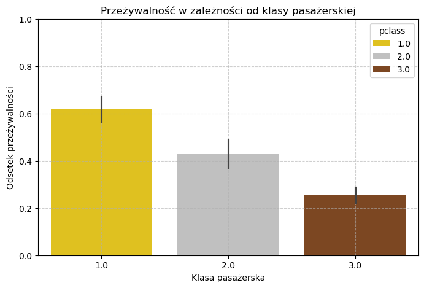

##### Wykres pokazuje, że pasażerowie podróżujący w wyższej klasie, mieli większe szanse na przeżycie (1 - klasa najwyższa, 3 - klasa najniższa).

#### Cena biletu, klasa pasażerska.

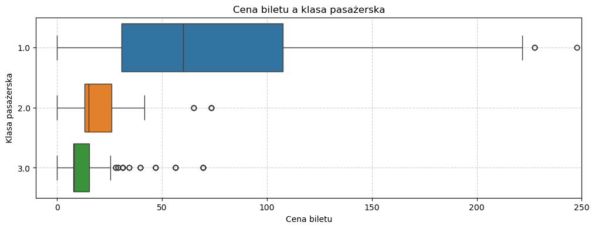

##### Z wykresu wynika, że 75% wawrtośći dla ceny biletu w klasie 3, jest poniżej 50% wartości cen biletu w klasie 2. Natomiast większość wartości cen biletów z klasy 3 i ponad 75% wartośći cen biletów z klasy 2 jest poniżej 25% wartości cen biletów w klasie 1.

#### Cena biletu, ocalenie.

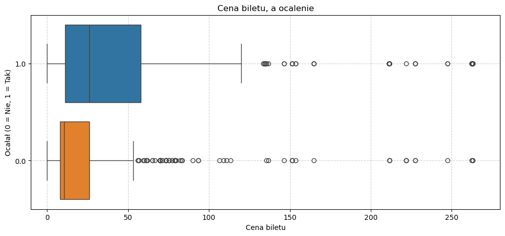

##### Wykres wykazuje, że cena jaką pasażer zapłacił za bilet, miała znczny wpływ na to, czy pasażer ocalał, czy nie.

##### Jednak patrząc na wartości odstające mamy sporo zbliżonych cen biletu zarówno wśród pasażerów, którzy przeżyli, jak i zmarli.

#### Ocaleni, płeć, klasa.

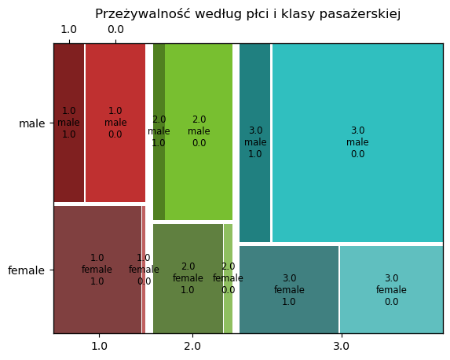

##### Kobiety przeważają pod względem ocalenia. Im wyższa klasa pasażerska, tym większy odsetek kobier ocalał. Wśród mężczyzn największy odsetek ocalałych jest w klasie 1.

#### Łodzie ratunkowe, klasa pasażerska.

| pclass | boat |
| --- | --- |
| 1.0 | 201 |
| 2.0 | 112 |
| 3.0 | 173 |

##### Na łodziach ratunkowych zarejestrowano 201 osób z klasy 1, 112osób z klasy 2 oraz 173 osoby z klasy 3.

#### Ciała ofiar z podziałem na klase.

| pclass | body |
| --- | --- |
| 1.0 | 35 |
| 2.0 | 31 |
| 3.0 | 55 |

##### Odnaleziono 35 ciał spośród ofiar z 1 klasy, 31 ciał spośród ofiar z 2 klasy, 55 ciał spośród ofiar z 3 klasy.

#### Macierz korelacji dla kolumn numerycznych.

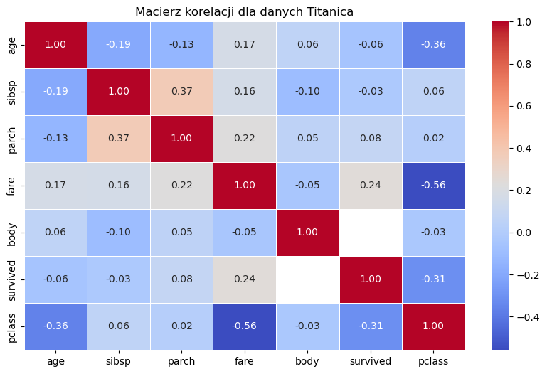

##### Widzimy korelację pomiędzy rodzinami(sibsp i parch). A także odwróconą korelacje pomiedzy klasą pasażerską(pclass), a wiekiem(age), ceną biletu(fare) i ocalonymi(survived).

# 6. Wartości odstające.

#### Cena biletu.

| pclass | count | mean | std | min | 25% | 50% | 75% | max |
| --- | --- | --- | --- | --- | --- | --- | --- | --- |
| 1.0 | 323.0 | 87.508992 | 80.447178 | 0.0 | 30.6958 | 60.0000 | 107.6625 | 512.3292 |
| 2.0 | 277.0 | 21.179196 | 13.607122 | 0.0 | 13.0000 | 15.0458 | 26.0000 | 73.5000 |
| 3.0 | 709.0 | 13.302885 | 11.486238 | 0.0 | 7.7500 | 8.0500 | 15.2458 | 69.5500 |

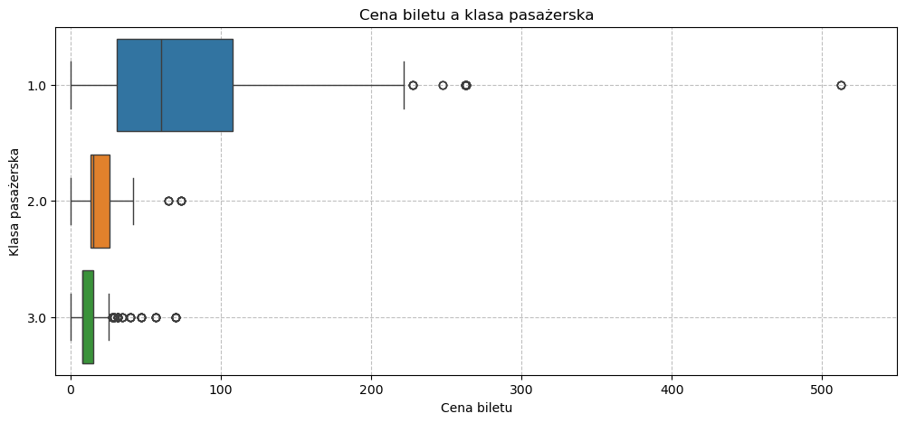

##### Wartości odstające dla cen biletów największą rozpiętość mają w klasie 1: w przybliżeniu od 220 do 520, w klasie 2 od 40 do 75, w klasie 3 od 25 do 70

#### Wiek.

|  | age |
| --- | --- |
| count | 1309.000000 |
| mean | 29.978610 |
| std | 12.889776 |
| min | 0.000000 |
| 25% | 22.000000 |
| 50% | 30.000000 |
| 75% | 35.000000 |
| max | 80.000000 |

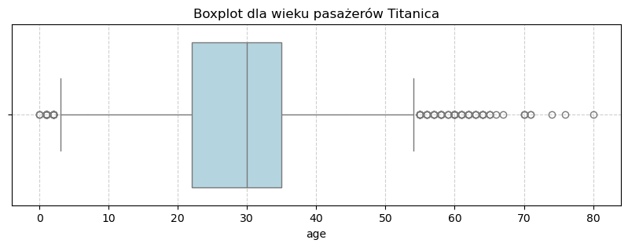

##### Dane o wieku posiadają wartości odstające zarówno przy wartościach minimalnych - poniżej 2 lat, jak i maksymalnych - powyżej 53 lata.

#### Liczba rodzeństwa, małżonków na pokładzie

|  | sibsp |
| --- | --- |
| count | 1309.000000 |
| mean | 0.498854 |
| std | 1.041658 |
| min | 0.000000 |
| 25% | 0.000000 |
| 50% | 0.000000 |
| 75% | 1.000000 |
| max | 8.000000 |

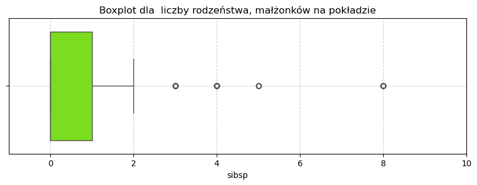

##### 75% onserwacji miało 1 członka rodziny na pokładzie, wartości odstające było sięgały 8 członków rodziny.

#### Liczba rodziców, dzieci na pokładzie.

|  | parch |
| --- | --- |
| count | 1309.000000 |
| mean | 0.385027 |
| std | 0.865560 |
| min | 0.000000 |
| 25% | 0.000000 |
| 50% | 0.000000 |
| 75% | 0.000000 |
| max | 9.000000 |

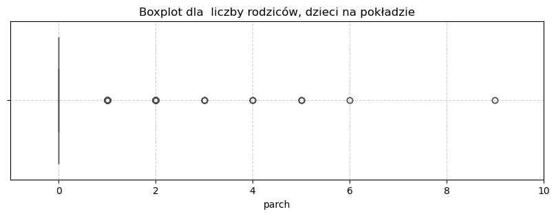

#### 75% obserwacji nie miało żadnego członka rodziny na pokładzie. Wartości odstające sięgały 9 członków rodziny.

# Podsumowanie

#### Przeżywalność:

Katastrofę przeżyło 38% pasażerów (500 osób), z czego zdecydowaną większość stanowiły kobiety (339 kobiet vs. 161 mężczyzn).

#### Klasa podróży:

Pasażerowie 1 klasy mieli najwyższy odsetek przeżycia (200 z 323 osób), w 2 klasie przeżyło 119 z 277 osób, w 3 klasie – 181 z 709 osób. Im wyższa klasa, tym większa szansa na przeżycie.

#### Płeć:

Na pokładzie było 466 kobiet i 843 mężczyzn. Kobiety miały zdecydowanie większą szansę na przeżycie niż mężczyźni.

# Podsumowanie

#### Wiek:

Średni wiek pasażerów wynosił ok. 30 lat, najmłodszy pasażer miał mniej niż rok, najstarszy 80 lat. Wiek nie miał jednoznacznego wpływu na przeżycie, ale dzieci i kobiety były częściej ratowane.

#### Cena biletu:

Średnia cena biletu to 33 jednostki walutowe, przy czym w 1 klasie średnio 87, w 2 klasie 21, w 3 klasie 13. Cena biletu silnie zależała od klasy i była powiązana z szansą przeżycia.

#### Port zaokrętowania:

Najwięcej pasażerów wsiadło w Southampton (914), następnie Cherbourg (270) i Queenstown (123).

# Podsumowanie

#### Braki danych:

Najwięcej brakujących wartości dotyczyło numerów kabin (1014), wieku (263), celu podróży (564), numerów łodzi ratunkowych (823) i ciał (1188). Braki w wieku i cenie biletu można uzupełnić średnimi wartościami dla płci/klasy.

#### Duplikaty:

Występowały powtarzające się numery biletów, ale były przypisane do różnych osób (np. rodziny).

#### Wartości odstające:

Dotyczyły głównie cen biletów (zwłaszcza w 1 klasie) oraz liczby członków rodziny na pokładzie.